# NLP_Que_4

MECE Table

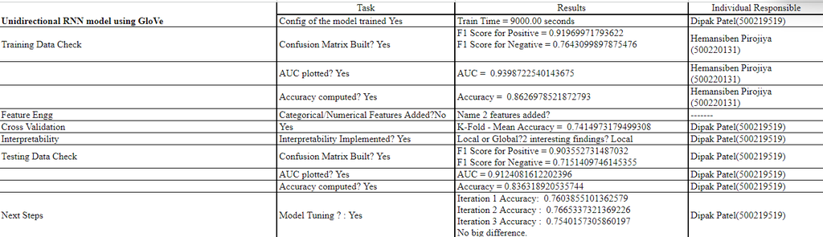

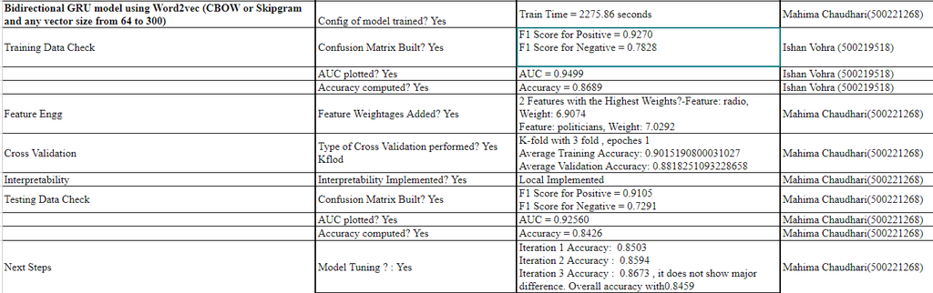

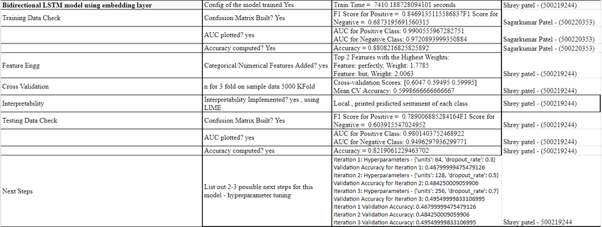

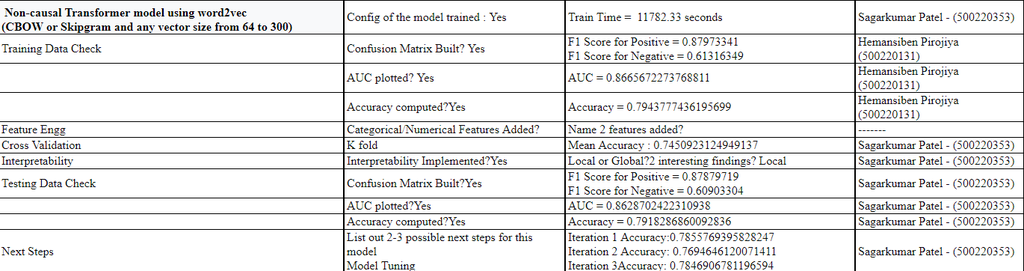

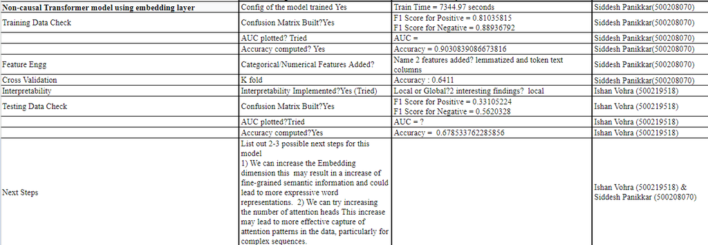

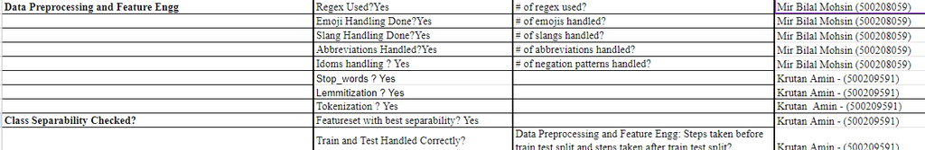

```python
#Importing libraries
import pandas as pd
import re
import nltk
from nltk.corpus import stopwords
from nltk.tokenize import word_tokenize
from nltk.stem import WordNetLemmatizer
from autocorrect import Speller
from sklearn.feature_extraction.text import TfidfVectorizer
from sklearn.decomposition import TruncatedSVD
from sklearn.preprocessing import LabelEncoder
from sklearn.model_selection import train_test_split
import matplotlib.pyplot as plt
```

```python
nltk.download('punkt')
nltk.download('wordnet')
nltk.download('stopwords')
```

```
True
```

```python
sagar= pd.read_csv('/content/Sentiment_Data.csv', encoding='latin-1')
```

```python
sagar.head(40)
```

|  | Tweet | Sentiment |
| --- | --- | --- |
| 0 | @_angelica_toy Happy Anniversary!!!....The Day... | Mild_Pos |
| 1 | @McfarlaneGlenda Happy Anniversary!!!....The D... | Mild_Pos |
| 2 | @thevivafrei @JustinTrudeau Happy Anniversary!... | Mild_Pos |
| 3 | @NChartierET Happy Anniversary!!!....The Day t... | Mild_Pos |
| 4 | @tabithapeters05 Happy Anniversary!!!....The D... | Mild_Pos |
| 5 | @JusticeStyle Happy Anniversary!!!....The Day ... | Mild_Pos |
| 6 | @Praiset22112963 @Emergencies_Act @ikwilson Ha... | Mild_Pos |
| 7 | @parnel1123 @RealAndyLeeShow Happy Anniversary... | Mild_Pos |
| 8 | Freedom Convoy as InkBlot Test https://t.co/au... | Strong_Pos |
| 9 | @WSOnlineNews @DavidKrayden Happy Anniversary!... | Mild_Pos |
| 10 | @TammyNiemi @Emergencies_Act Happy Anniversary... | Mild_Pos |
| 11 | @westglassart @Emergencies_Act Happy Anniversa... | Mild_Pos |
| 12 | @James_Mc666 Happy Anniversary!!!....The Day t... | Mild_Pos |
| 13 | @mark_slapinski Well itâs pretty easy to see... | Strong_Pos |
| 14 | @Bird5Ca Happy Anniversary!!!....The Day the F... | Mild_Pos |
| 15 | @HenriAGS Happy Anniversary!!!....The Day the ... | Mild_Pos |
| 16 | @ShaunRickard67 @brianlilley Happy Anniversary... | Mild_Pos |
| 17 | @canadiancynic Happy Anniversary!!!....The Day... | Mild_Pos |
| 18 | @lak_ted Happy Anniversary!!!....The Day the F... | Mild_Pos |
| 19 | @DavidKrayden Happy Anniversary!!!....The Day ... | Mild_Pos |
| 20 | @brianlilley Happy Anniversary!!!....The Day t... | Mild_Pos |
| 21 | @TheTorontoSun Happy Anniversary!!!....The Day... | Mild_Pos |
| 22 | @TheBeaverton Happy Anniversary!!!....The Day ... | Mild_Pos |
| 23 | @JustinTrudeau You Belong In Jail.\n#VaccineMa... | Neutral |
| 24 | @1MikeMorris Happy Anniversary!!!....The Day t... | Mild_Pos |
| 25 | #FreeDumbConvoy #FreedomConvoy #Freedumbers #f... | Neutral |
| 26 | @DNArigged Happy Anniversary!!!....The Day the... | Mild_Pos |
| 27 | Happy Anniversary!!!....The Day the FreeDUMB D... | Mild_Pos |
| 28 | @Garnet_2203 @TuckerCarlson @mini_bubbly Your ... | Strong_Pos |
| 29 | @CPC_HQ The Freedom Convoy you supported, whic... | Strong_Pos |
| 30 | #FreedomConvoy https://t.co/cF1ohIQ5dK | Neutral |
| 31 | @brethordark The #FreedomConvoy 1 year Anniver... | Strong_Neg |
| 32 | @FightHaven Those knee drops remind me of some... | Mild_Neg |
| 33 | Canadaâs Freedom Radio! hosted by Freedom Co... | Strong_Pos |
| 34 | #freedomconvoy https://t.co/levc86wFp3 | Neutral |
| 35 | The Freedom Convoy inspired global protests ag... | Strong_Pos |
| 36 | @AndreLemelin4 We are a sovereign nation with ... | Mild_Neg |
| 37 | Canadians are too weak to ever push the "Freed... | Strong_Pos |
| 38 | KRAYDEN: Freedom Convoy lawyer: âTrudeau sho... | Strong_Pos |
| 39 | @ClintonDesveaux Canadians are too weak to eve... | Strong_Pos |

DATA PREPROCESSING

```python
def preprocess_text(text):
    if isinstance(text, str):

        text = text.lower()

        text = re.sub(r'http\S+', '', text)


        text = re.sub(r'[^a-z#@]', ' ', text)

        text = re.sub(r'@[A-Za-z0-9]+', '', text)

        text = re.sub(r'#', '', text)

        text = re.sub(r'\s+', ' ', text).strip()

        text = re.sub(r'\b[\w\-.]+?@\w+?\.\w{2,4}\b', '', text)

        text = re.sub(r'@\w+', '', text)

        text = re.sub(r'\b\w{1,2}\b', '', text)

    return text
```

```python
sagar['lemmatized_tweet'] = sagar['Tweet'].apply(preprocess_text)
```

```python
sagar.head(5)
```

|  | Tweet | Sentiment | lemmatized_tweet |
| --- | --- | --- | --- |
| 0 | @_angelica_toy Happy Anniversary!!!....The Day... | Mild_Pos | @ angelica toy happy anniversary the day the f... |
| 1 | @McfarlaneGlenda Happy Anniversary!!!....The D... | Mild_Pos | happy anniversary the day the freedumb died t... |
| 2 | @thevivafrei @JustinTrudeau Happy Anniversary!... | Mild_Pos | happy anniversary the day the freedumb died t... |
| 3 | @NChartierET Happy Anniversary!!!....The Day t... | Mild_Pos | happy anniversary the day the freedumb died t... |
| 4 | @tabithapeters05 Happy Anniversary!!!....The D... | Mild_Pos | happy anniversary the day the freedumb died t... |

```python
def slang(text):

    slang_dict = {
    "lol": "laugh out loud",
    "brb": "be right back",
    "btw": "by the way",
    "idk": "I don't know",
    "omg": "oh my god",
    "tbh": "to be honest",
    "bff": "best friends forever",
    "smh": "shake my head",
    "imo": "in my opinion",
    "fyi": "for your information",
    "irl": "in real life",
    "rofl": "rolling on the floor laughing",
    "gtg": "got to go",
    "tyt": "take your time",
    "af": "as fuck",
    "ftw": "for the win",
    "hmu": "hit me up",
    "tb": "throwback",
    "tmi": "too much information",
    "omw": "on my way",
    "np": "no problem",
    "smh": "shaking my head",
    "wyd": "what are you doing",
    "wya": "where you at",
    "nvm": "never mind",
    "gg": "good game",
    "jsyk": "just so you know",
    "imo": "in my opinion",
    "hmu": "hit me up",
    "afk": "away from keyboard",
    "jk": "just kidding",
    "dm": "direct message",
    "rt": "retweet",
    "dm": "direct message",
    "yolo": "you only live once",
    "fomo": "fear of missing out",
    "tfw": "that feeling when",
    "ootd": "outfit of the day",
    "fml": "fuck my life",
    "smfh": "shaking my fucking head",
    "tbt": "throwback Thursday",
    "ff": "follow Friday",
    "btfo": "blown the fuck out",
    "wcw": "woman crush Wednesday",
    "mcm": "man crush Monday",
    "bae": "before anyone else"
}


    if isinstance(text, str):
        return ' '.join(slang_dict.get(word, word) for word in text.split())
    else:
        return text
```

```python
sagar['lemmatized_tweet'] = sagar['lemmatized_tweet'].apply(slang)
```

```python
def abbreviations(text):
    abbreviation_dict = {
        "u": "you",
        "r": "are",
        "2": "to",
        "gr8": "great",
        "bc": "because",
        "w/o": "without",
        "msg": "message",
        "pls": "please",
        "thx": "thanks",
        "wtf": "what the f***",
        "omg": "oh my god",
        "fyi": "for your information",
        "imo": "in my opinion",
        "idk": "I don't know",
        "lol": "laughing out loud",
        "btw": "by the way",
        "omw": "on my way",
        "hmu": "hit me up",
        "tbh": "to be honest",
        "tmi": "too much information",
        "fyi": "for your information",
        "smh": "shaking my head",
        "imho": "in my humble opinion",
        "fomo": "fear of missing out",
        "af": "as f***",
        "bff": "best friends forever",
        "ftw": "for the win",
        "gtg": "got to go",
        "hmu": "hit me up",
        "irl": "in real life",
        "lmao": "laughing my ass off",
        "rofl": "rolling on the floor laughing",
        "wcw": "woman crush Wednesday",
        "mcm": "man crush Monday",
        "smh": "shaking my head",
        "wyd": "what you doing",
        "yolo": "you only live once",
        "tbt": "throwback Thursday",
        "icymi": "in case you missed it",
        "brb": "be right back",
        "smdh": "shaking my damn head",
        "gtfo": "get the f*** out",
        "idc": "I don't care",
        "imo": "in my opinion",
        "idk": "I don't know"
    }


    if isinstance(text, str):
        return ' '.join(abbreviation_dict.get(word, word) for word in text.split())
    else:
        return text
```

```python
sagar['lemmatized_tweet'] = sagar['lemmatized_tweet'].apply(abbreviations)
```

```python
def idioms(text):
    idiom_dict = {
        "wait to": "excited about",
        "can't wait": "excited about",
        "rain on my parade": "spoil my plans",
        "hit the hay": "go to bed",
        "cost an arm and a leg": "very expensive",
        "raining cats and dogs": "heavy rain",
        "under the weather": "not feeling well",
        "piece of cake": "very easy",
        "burn the midnight oil": "work late into the night",
        "break a leg": "good luck",
        "spill the beans": "reveal a secret",
        "in hot water": "in trouble",
        "jump on the bandwagon": "join a popular trend",
        "kick the bucket": "pass away",
        "needle in a haystack": "hard to find",
        "out of the blue": "unexpectedly",
        "cold feet": "nervous",
        "once in a blue moon": "rarely",
        "barking up the wrong tree": "mistaken",
        "elephant in the room": "obvious issue",
        "back to the drawing board": "start over",
        "break the ice": "relieve tension",
        "by the skin of your teeth": "barely succeed",
        "call it a day": "end work",
        "caught red-handed": "caught in the act",
        "cry over spilled milk": "regret something already done"

    }

    if isinstance(text, str):
        return ' '.join(idiom_dict.get(word, word) for word in text.split())
    else:
        return text
```

```python
sagar['lemmatized_tweet'] = sagar['lemmatized_tweet'].apply(idioms)
```

```python
def tokenization(text):
    if isinstance(text, str):
        return word_tokenize(text)
    else:
        return []
```

```python
sagar['tokens'] = sagar['lemmatized_tweet'].apply(tokenization)
```

```python
def remove_stopwords(tokens):
    if isinstance(tokens, list):
        return [word for word in tokens if word not in stopwords.words('english')]
    else:
        return []
```

```python
sagar['tokens'] = sagar['tokens'].apply(remove_stopwords)
```

```python
def lemmatization(tokens):
    if isinstance(tokens, list):
        lemmatizer = WordNetLemmatizer()
        return ' '.join(lemmatizer.lemmatize(token) for token in tokens)
    else:
        return ''
```

```python
sagar['lemmatized_tweet'] = sagar['tokens'].apply(lemmatization)
```

```python
sagar.to_csv('sagar_preprocessed.csv', index=False)
```

```python
sagar.head(5)
```

|  | Tweet | Sentiment | lemmatized_tweet | tokens |
| --- | --- | --- | --- | --- |
| 0 | @_angelica_toy Happy Anniversary!!!....The Day... | Mild_Pos | @ angelica toy happy anniversary day freedumb ... | [@, angelica, toy, happy, anniversary, day, fr... |
| 1 | @McfarlaneGlenda Happy Anniversary!!!....The D... | Mild_Pos | happy anniversary day freedumb died tune mclea... | [happy, anniversary, day, freedumb, died, tune... |
| 2 | @thevivafrei @JustinTrudeau Happy Anniversary!... | Mild_Pos | happy anniversary day freedumb died tune mclea... | [happy, anniversary, day, freedumb, died, tune... |
| 3 | @NChartierET Happy Anniversary!!!....The Day t... | Mild_Pos | happy anniversary day freedumb died tune mclea... | [happy, anniversary, day, freedumb, died, tune... |
| 4 | @tabithapeters05 Happy Anniversary!!!....The D... | Mild_Pos | happy anniversary day freedumb died tune mclea... | [happy, anniversary, day, freedumb, died, tune... |

## **Model Implementation**

```python
import numpy as np
import pandas as pd
from sklearn.model_selection import train_test_split
from keras.preprocessing.text import Tokenizer
from keras.preprocessing.sequence import pad_sequences
from keras.utils import to_categorical
from keras.models import Sequential
from keras.layers import Embedding, LSTM, Dense, Dropout, Attention
from keras.callbacks import EarlyStopping
from sklearn.metrics import classification_report, accuracy_score, roc_auc_score, confusion_matrix
```

```python
# DefinING function to convert text to word2vec vectors
def text_to_vectors(text, word_vectors):
    vectors = []
    for word in text:
        if word in word_vectors:
            vectors.append(word_vectors[word])
    return np.array(vectors)
```

```python
# Loading word2vec embeddings
word_vectors = {}
```

```python
# Mapping sentiment classes
sagar['Sentiment'] = sagar['Sentiment'].replace({'Strong_Pos': 'Positive', 'Mild_Pos': 'Positive',
                                                 'Strong_Neg': 'Negative', 'Mild_Neg': 'Negative'})
```

```python
# Preparing input and target data
input = sagar['lemmatized_tweet']
output = sagar['Sentiment']
```

```python
from keras.layers import Input, Dense, GlobalAveragePooling1D
from keras.models import Model
```

```python
from gensim.models import KeyedVectors

# Loading word2vec embeddings
word2vec_model_path = '/content/wiki.vi.model.bin'
word2vec_model = KeyedVectors.load_word2vec_format(word2vec_model_path, binary=True)
```

```python
import tensorflow as tf
from tensorflow.keras.layers import Layer
```

```python
# Defining  the TransformerBlock layer
class TransformerBlock(Layer):
    def __init__(self, embedding_dim, num_heads, dff, rate=0.1):
        super(TransformerBlock, self).__init__()

        self.attention = MultiHeadAttention(num_heads=num_heads, key_dim=embedding_dim // num_heads)
        self.ffn = Sequential([
            Dense(dff, activation='relu'),
            Dense(embedding_dim)
        ])

        self.layernorm1 = LayerNormalization(epsilon=1e-6)
        self.layernorm2 = LayerNormalization(epsilon=1e-6)

        self.dropout1 = Dropout(rate)
        self.dropout2 = Dropout(rate)

    def call(self, inputs, training=False):
        attn_output = self.attention(inputs, inputs)
        attn_output = self.dropout1(attn_output, training=training)
        out1 = self.layernorm1(inputs + attn_output)

        ffn_output = self.ffn(out1)
        ffn_output = self.dropout2(ffn_output, training=training)
        out2 = self.layernorm2(out1 + ffn_output)

        return out2
```

```python
# Tokenizinging text
tokenizer = Tokenizer()
tokenizer.fit_on_texts(input)
X_seq = tokenizer.texts_to_sequences(X)

# Padding sequences
max_sequence_length = max([len(seq) for seq in X_seq])
X_pad = pad_sequences(X_seq, maxlen=max_sequence_length)

# Converting sentiment labels into categorical values
sentiment_mapping = {'Positive': 0, 'Neutral': 1, 'Negative': 2}
y_categorical = [sentiment_mapping[sentiment] for sentiment in output]
y_categorical = to_categorical(y_categorical)
```

```python
# Train-test split
X_train, X_test, y_train, y_test = train_test_split(X_pad, y_categorical, test_size=0.2, random_state=42)
```

```python
# Creating word_index dictionary
word_index = tokenizer.word_index
# Defining num_words
num_words = len(word_index) + 1

embedding_dim = word2vec_model.vector_size

# Creating embedding matrix
embedding_matrix = np.zeros((num_words, embedding_dim))

# Creating embedding matrix
embedding_matrix = np.zeros((num_words, embedding_dim))
for word, i in word_index.items():
    if i < num_words:
        if word in word2vec_model:
            embedding_matrix[i] = word2vec_model[word]
```

```python
# Create the transformer model
def create_transformer_model(max_sequence_length, num_classes, embedding_dim):
    inputs = Input(shape=(max_sequence_length,))
    embedding_layer = Embedding(num_words, embedding_dim, weights=[embedding_matrix], input_length=max_sequence_length, trainable=False)(inputs)
    transformer_block = TransformerBlock(embedding_dim, num_heads=2, dff=64, rate=0.1)(embedding_layer)
    average_pooling = GlobalAveragePooling1D()(transformer_block)
    outputs = Dense(num_classes, activation='softmax')(average_pooling)
    model = Model(inputs=inputs, outputs=outputs)
    return model
```

```python
from tensorflow.keras.layers import MultiHeadAttention
from tensorflow.keras.layers import LayerNormalization


# Defiinge number of classes
num_classes = 3

# Creating the transformer model
model = create_transformer_model(max_sequence_length, num_classes, embedding_dim)

# Compiling the model
model.compile(optimizer='adam', loss='categorical_crossentropy', metrics=['accuracy'])
```

```python
import time


start_time = time.time()

# Training the model
model.fit(X_train, y_train, batch_size=64, epochs=5, validation_data=(X_test, y_test))

end_time = time.time()
```

```python
training_time = end_time - start_time


print("Training Time: {:.2f} seconds".format(training_time))
```

```
Training Time: 11782.33 seconds
```

```python
# Evaluating the model
loss, accuracy = model.evaluate(X_test, y_test)
print("Test Accuracy:", accuracy)
```

```
Test Accuracy: 0.7918286919593811
```

```python
from sklearn.metrics import accuracy_score, roc_auc_score, confusion_matrix, classification_report, f1_score

# MAking Predictions on training set
y_train_pred = model.predict(X_train)
y_train_pred_class = np.argmax(y_train_pred, axis=1)

#Making Predictions on testing set
y_test_pred = model.predict(X_test)
y_test_pred_class = np.argmax(y_test_pred, axis=1)
```

```python
# Finding accuracy
train_accuracy = accuracy_score(np.argmax(y_train, axis=1), y_train_pred_class)
test_accuracy = accuracy_score(np.argmax(y_test, axis=1), y_test_pred_class)
print("Training Accuracy:", train_accuracy)
print("Testing Accuracy:", test_accuracy)

# Finding AUC
train_auc = roc_auc_score(y_train, y_train_pred)
test_auc = roc_auc_score(y_test, y_test_pred)
print("Training AUC:", train_auc)
print("Testing AUC:", test_auc)
```

```
Training Accuracy: 0.7943777436195699
Testing Accuracy: 0.7918286860092836
Training AUC: 0.8665672273768811
Testing AUC: 0.8628702422310938
```

```python
# Finding confusion matrix
train_confusion_matrix = confusion_matrix(np.argmax(y_train, axis=1), y_train_pred_class)
test_confusion_matrix = confusion_matrix(np.argmax(y_test, axis=1), y_test_pred_class)
print("Training Confusion Matrix:")
print(train_confusion_matrix)
print("Testing Confusion Matrix:")
print(test_confusion_matrix)

# Finding F1 score for positive and negative classes
train_f1_positive = f1_score(np.argmax(y_train, axis=1), y_train_pred_class, labels=[0], average=None)
test_f1_positive = f1_score(np.argmax(y_test, axis=1), y_test_pred_class, labels=[0], average=None)

train_f1_negative = f1_score(np.argmax(y_train, axis=1), y_train_pred_class, labels=[2], average=None)
test_f1_negative = f1_score(np.argmax(y_test, axis=1), y_test_pred_class, labels=[2], average=None)

print("Training F1 Score (Positive):", train_f1_positive)
print("Testing F1 Score (Positive):", test_f1_positive)

print("Training F1 Score (Negative):", train_f1_negative)
print("Testing F1 Score (Negative):", test_f1_negative)
```

```
Training Confusion Matrix:
[[229416   3449   5371]
 [ 30040  25107   6443]
 [ 23866   5074  32299]]
Testing Confusion Matrix:
[[57193   898  1377]
 [ 7514  6199  1713]
 [ 5987  1302  8084]]
Training F1 Score (Positive): [0.87973341]
Testing F1 Score (Positive): [0.87879719]
Training F1 Score (Negative): [0.61316349]
Testing F1 Score (Negative): [0.60903304]
```

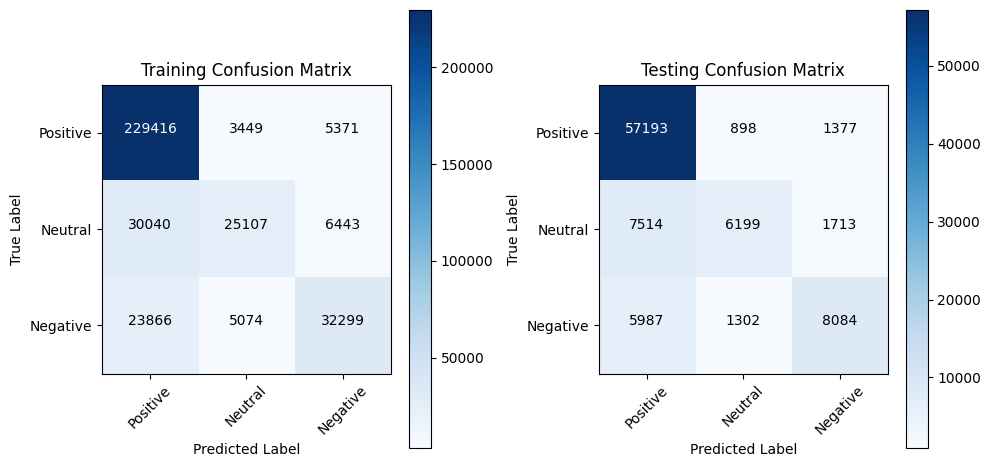

```python
import matplotlib.pyplot as plt
from sklearn.metrics import roc_curve, auc

# Plotting Confusion Matrix
plt.figure(figsize=(10, 5))

plt.subplot(1, 2, 1)
plt.title('Training Confusion Matrix')
plt.imshow(train_confusion_matrix, interpolation='nearest', cmap=plt.cm.Blues)
plt.colorbar()
tick_marks = np.arange(len(sentiment_mapping))
plt.xticks(tick_marks, list(sentiment_mapping.keys()), rotation=45)
plt.yticks(tick_marks, list(sentiment_mapping.keys()))
plt.xlabel('Predicted Label')
plt.ylabel('True Label')

for i in range(train_confusion_matrix.shape[0]):
    for j in range(train_confusion_matrix.shape[1]):
        plt.text(j, i, format(train_confusion_matrix[i, j], 'd'),
                 horizontalalignment="center",
                 color="white" if train_confusion_matrix[i, j] > train_confusion_matrix.max() / 2 else "black")

plt.subplot(1, 2, 2)
plt.title('Testing Confusion Matrix')
plt.imshow(test_confusion_matrix, interpolation='nearest', cmap=plt.cm.Blues)
plt.colorbar()
tick_marks = np.arange(len(sentiment_mapping))
plt.xticks(tick_marks, list(sentiment_mapping.keys()), rotation=45)
plt.yticks(tick_marks, list(sentiment_mapping.keys()))
plt.xlabel('Predicted Label')
plt.ylabel('True Label')

for i in range(test_confusion_matrix.shape[0]):
    for j in range(test_confusion_matrix.shape[1]):
        plt.text(j, i, format(test_confusion_matrix[i, j], 'd'),
                 horizontalalignment="center",
                 color="white" if test_confusion_matrix[i, j] > test_confusion_matrix.max() / 2 else "black")

plt.tight_layout()
plt.show()
```

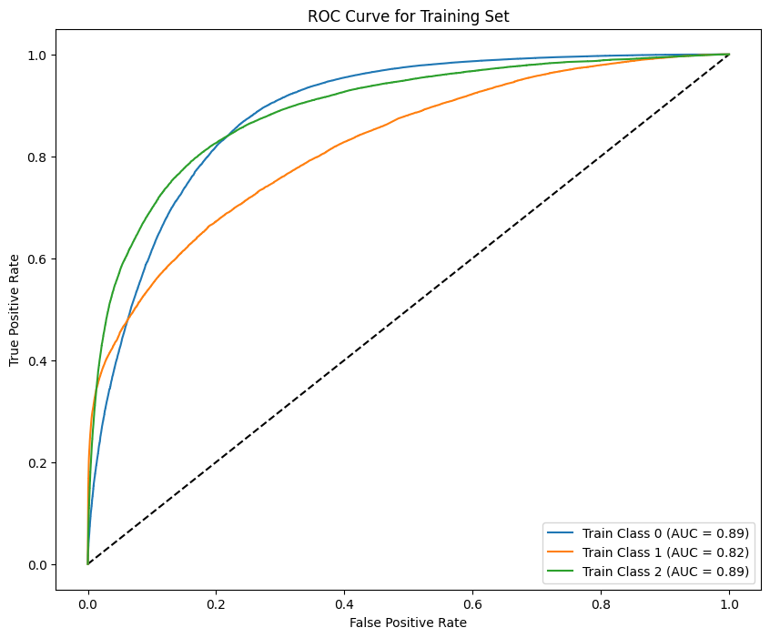

```python
import matplotlib.pyplot as plt
from sklearn.metrics import roc_curve, auc

# Finding ROC curve and ROC area for each class
fpr_train = dict()
tpr_train = dict()
roc_auc_train = dict()

for i in range(3):
    fpr_train[i], tpr_train[i], _ = roc_curve(y_train[:, i], y_train_pred[:, i])
    roc_auc_train[i] = auc(fpr_train[i], tpr_train[i])

# Plotting ROC curve for training set
plt.figure(figsize=(10, 8))
plt.plot([0, 1], [0, 1], 'k--')

for i in range(3):
    plt.plot(fpr_train[i], tpr_train[i], label='Train Class {} (AUC = {:.2f})'.format(i, roc_auc_train[i]))

plt.xlabel('False Positive Rate')
plt.ylabel('True Positive Rate')
plt.title('ROC Curve for Training Set')
plt.legend(loc="lower right")
plt.show()
```

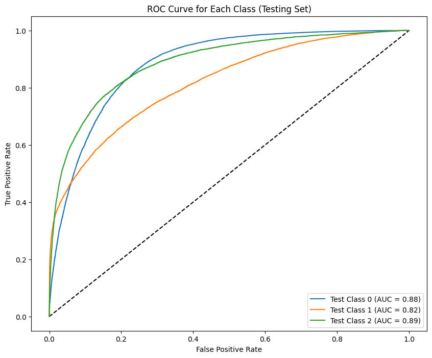

```python
import matplotlib.pyplot as plt
from sklearn.metrics import roc_curve, auc

# Finding ROC curve and ROC area for each class
fpr_test = dict()
tpr_test = dict()
roc_auc_test = dict()

for i in range(3):
    fpr_test[i], tpr_test[i], _ = roc_curve(y_test[:, i], y_test_pred[:, i])
    roc_auc_test[i] = auc(fpr_test[i], tpr_test[i])

# Plotting ROC curve for each class separately
plt.figure(figsize=(10, 8))
plt.plot([0, 1], [0, 1], 'k--')

for i in range(3):
    plt.plot(fpr_test[i], tpr_test[i], label='Test Class {} (AUC = {:.2f})'.format(i, roc_auc_test[i]))

plt.xlabel('False Positive Rate')
plt.ylabel('True Positive Rate')
plt.title('ROC Curve for Each Class (Testing Set)')
plt.legend(loc="lower right")
plt.show()
```

```python
from sklearn.model_selection import train_test_split, KFold
```

```python
from sklearn.model_selection import KFold

# Defining the number of folds for cross-validation
num_folds = 3

split_index = len(X_pad) // 4


X_set = X_pad[:split_index]
y_set = y_categorical[:split_index]

# Initialize KFold
kf = KFold(n_splits=num_folds, shuffle=True, random_state=42)

accuracy_scores = []

# Performing cross-validation
fold_index = 1
for train_index, test_index in kf.split(X_set):
    print(f"Fold {fold_index}/{num_folds}:")
    X_train_fold, X_val_fold = X_set[train_index], X_set[test_index]
    y_train_fold, y_val_fold = y_set[train_index], y_set[test_index]


    model = create_transformer_model(max_sequence_length, num_classes, embedding_dim)
    model.compile(optimizer='adam', loss='categorical_crossentropy', metrics=['accuracy'])


    model.fit(X_train_fold, y_train_fold, batch_size=64, epochs=3, validation_data=(X_val_fold, y_val_fold))

    _, accuracy = model.evaluate(X_val_fold, y_val_fold)
    print("Validation Accuracy:", accuracy)
    accuracy_scores.append(accuracy)

    fold_index += 1

# Calculate and print average accuracy across folds
avg_accuracy = np.mean(accuracy_scores)
print("Average Accuracy:", avg_accuracy)
```

```
Fold 1/3:
Validation Accuracy: 0.7360081076622009
Fold 2/3:
Validation Accuracy: 0.7456329464912415
Fold 3/3:
Validation Accuracy: 0.7536358833312988
Average Accuracy: 0.7450923124949137
```

```python
pip install lime
```

```
     ━━━━━━━━━━━━━━━━━━━━━━━━━━━━━━━━━━━━━━━━ 275.7/275.7 kB 3.6 MB/s eta 0:00:00
  Preparing metadata (setup.py) ... done
```

```python
import numpy as np
from lime.lime_text import LimeTextExplainer

# Defining sentiment mapping
sentiment_mapping = {'Positive': 1, 'Neutral': 0, 'Negative': -1}

# Creating LimeTextExplainer
explainer = LimeTextExplainer(class_names=list(sentiment_mapping.keys()))

# Choosing a sample for explanation
sample_index = 9000  # Change this index as needed
sample_text = input[sample_index]
true_sentiment = output[sample_index]

# Defining a function to predict probabilities using the model
def predict_proba(texts):
    sequences = tokenizer.texts_to_sequences(texts)
    padded_sequences = pad_sequences(sequences, maxlen=max_sequence_length)
    return model.predict(padded_sequences)

# Generateinglocal explanation
explanation = explainer.explain_instance(sample_text, predict_proba, num_features=10)

# Print true sentiment and local explanation
print("True Sentiment:", true_sentiment)
explanation.show_in_notebook(text=True)
```

```
True Sentiment: Positive
```

```python
def create_transformer_model(max_sequence_length, num_classes, embedding_dim, num_heads, dff, rate):
    inputs = Input(shape=(max_sequence_length,))
    embedding_layer = Embedding(num_words, embedding_dim, weights=[embedding_matrix], input_length=max_sequence_length, trainable=False)(inputs)
    transformer_block = TransformerBlock(embedding_dim, num_heads, dff, rate)(embedding_layer)
    average_pooling = GlobalAveragePooling1D()(transformer_block)
    outputs = Dense(num_classes, activation='softmax')(average_pooling)
    model = Model(inputs=inputs, outputs=outputs)
    return model
```

```python
from sklearn.model_selection import train_test_split

# Split the data into training and testing sets, taking 25% of the total data for training
X_train, X_test, y_train, y_test = train_test_split(X_pad, y_categorical, test_size=0.25, random_state=42)

# Define hyperparameters to tune for the first iteration
hyperparameters_iteration1 = {
    'num_heads': [2, 4],
    'dff': [64, 128],
    'rate': [0.1, 0.2]
}

# Define hyperparameters to tune for the second iteration (with rational changes)
hyperparameters_iteration2 = {
    'num_heads': [4, 8],
    'dff': [128, 256],
    'rate': [0.2, 0.3]
}

# Performing hyperparameter tuning
for iteration, hyperparameters in enumerate([hyperparameters_iteration1, hyperparameters_iteration2], start=1):
    print(f"Iteration {iteration}:")
    for num_heads in hyperparameters['num_heads']:
        for dff in hyperparameters['dff']:
            for rate in hyperparameters['rate']:
                print(f"Hyperparameters: num_heads={num_heads}, dff={dff}, rate={rate}")

                # Create and compile the model with current hyperparameters
                model = create_transformer_model(max_sequence_length, num_classes, embedding_dim, num_heads, dff, rate)
                model.compile(optimizer='adam', loss='categorical_crossentropy', metrics=['accuracy'])

                # Train the model
                model.fit(X_train, y_train, batch_size=64, epochs=3, validation_split=0.2)

                # Evaluate the model on the testing set
                _, accuracy = model.evaluate(X_test, y_test)
                print("Testing Accuracy:", accuracy)

                # Print accuracy and hyperparameters for each iteration
                print("Accuracy:", accuracy)
                print("Hyperparameters:", f"num_heads={num_heads}, dff={dff}, rate={rate}")
                print()
```

[output not shown]

**Rational changes**

- **Number of Heads (num_heads):**

**first iteration :** I consider [2, 4] as the possible values for the number of heads.

**second iteration :** I increased the range to [4, 8]. This change allows me to explore larger values for the number of heads, potentially capturing more complex patterns in the data.

- **Dimension of Feedforward Network:**
- **first iteration :** I considered [64, 128] as the possible values for the dimension of the feedforward network.
- **second iteration :** I increased the range to [128, 256]. By doing so, I aimed to explore larger dimensions for the feedforward network, which might capture more intricate relationships in the data.
- **Dropout Rate**
- **first iteration :**I consider [0.1, 0.2] as the possible values for the dropout rate.
- **second iteration :** I increased the range to [0.2, 0.3]. This change introduces higher dropout rates, which can help prevent overfitting by regularizing the model more effectively.

```python
!jupyter nbconvert --to html NLP_Que_4.ipynb
```

```
[NbConvertApp] Converting notebook NLP_Que_4.ipynb to html
[NbConvertApp] Writing 2813317 bytes to NLP_Que_4.html
```